# Week4Lab

JamesDale

2/11/2020

```r
population <- ames$Gr.Liv.Area
samp <- sample(population, 60)
```

## The Data

The Ames data set consists of **82 columns** and **2930 rows**.

## Exercise 1

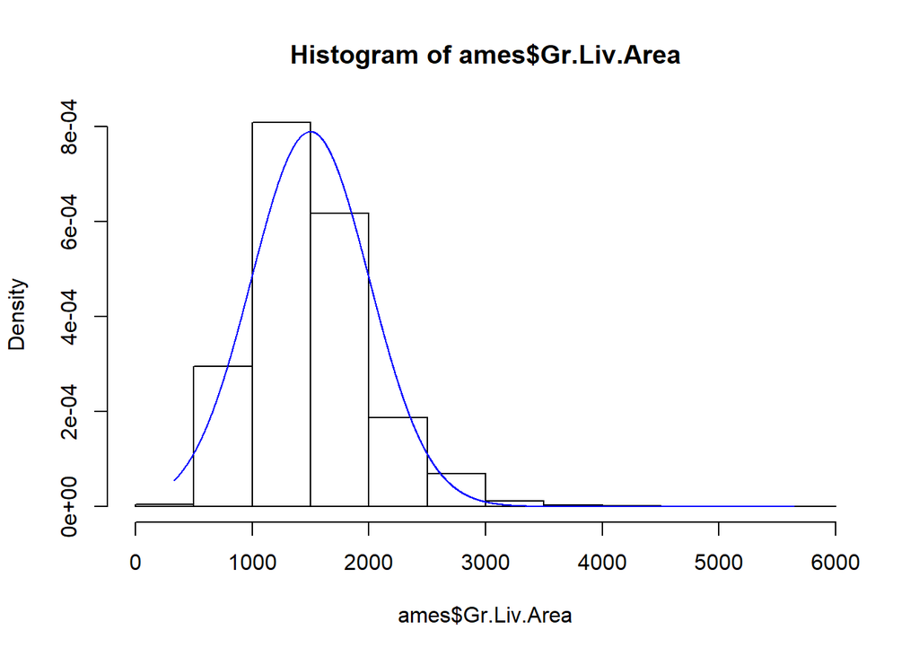

```r
gr_liv_area_mean <- mean(ames$Gr.Liv.Area)
gr_liv_area_ds <- sd(ames$Gr.Liv.Area)
hist(ames$Gr.Liv.Area, probability = TRUE)
hist_x <- min(ames$Gr.Liv.Area) : max(ames$Gr.Liv.Area)
hist_y <- dnorm(x = hist_x, mean = gr_liv_area_mean, sd = gr_liv_area_ds)
lines(x=hist_x, y=hist_y, col = 'blue')
```

#### I would estimate typical size in this sample to be **1442**. This estimate is based on the histogram shown above. We can see the distribution of area is right skewed, therefore I used the median value to best represent the middle of the data. I interprete typical to mean if I randomly asked someone how the area of their house it would be around this number.

## Exercise 2

#### Given that it is a random sample size of 60 from a population I wouldn’t expect the distribution to be identical however, I would expect it to be simular because it is a random sample of a fairly large size.

### Confidence intervals

```r
sample_mean <- mean(samp)
se <- sd(samp) / sqrt(60)
lower <- sample_mean - 1.96 * se
upper <- sample_mean + 1.96 * se
c(lower, upper)
```

```
## [1] 1360.094 1593.973
```

## Exercise 3

#### **Conditions for Confidence intervals**

- The sample observations are independent
- The sample size is large
- The poplation distribution is not strongly skewed

## Exercise 4

#### A confidence interval is a range defined around the point estimate. The stardard error determines how large this range is. 95% confidence interval means roughly 95% of values will contain the actual mean.

```r
# True population mean
mean(population)
```

```
## [1] 1499.69
```

## Exercise 5

```r
if ((mean(population) >= lower) & (mean(population) <= upper)){
  "My confidence interval contains the population mean."
} else{
  "My confidence interval does notcontain the population mean."
}
```

```
## [1] "My confidence interval contains the population mean."
```

#### If my neighbor has the same sample then we would most likely have the same confidence interval. If they have a different sample from the sample population the confidence inverals will vary slightly.

## Excercise 6

```r
samp_mean <- rep(NA, 50)
samp_sd <- rep(NA, 50)
n <- 60
for(i in 1:50){
  samp <- sample(population, n)
  samp_mean[i] <- mean(samp)
  samp_sd[i] <- sd(samp)
}
lower_vector <- samp_mean - 1.96 * samp_sd / sqrt(n)
upper_vector <- samp_mean + 1.96 * samp_sd / sqrt(n)

c(lower_vector[1], upper_vector[1])
```

```
## [1] 1363.043 1614.857
```

### Below shows the range of confidence intervals for all 50 samples

```r
p = plot_ly(type = "scatter", mode = 'markers')
for ( i in 1:50){p <- add_trace(p, x = c(lower_vector[i], upper_vector[i]), y = c(i, i), mode = 'lines', showlegend = FALSE, line=list(color = 'black'))}
p <- add_trace(p, x = c(mean(population), mean(population)), y = c(0,51), mode = 'lines', showlegend = FALSE)
p
```

[interactive chart not shown]

### Below shows the number of sample confidence intervals that capture population mean

```r
num_within <- 0
for (i in 1:50){if((lower_vector[i] <= mean(population))&(upper_vector[i] >= mean(population))){num_within<- num_within + 1}}
num_within
```

```
## [1] 47
```

### There are **47** confidence intervals that capture the population mean out of 50.

## Activity 1

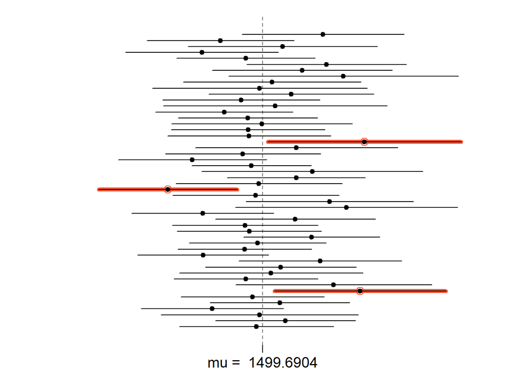

```r
# I wish i checked out out this function before fighting with the Plotly library
plot_ci(lower_vector, upper_vector, mean(population))
```

### The proportion of confidence intervals that capture the population mean is **0.94**.

## Activity 2

### Choose 90% confidence interval. The appropraite critical value is 1.64.

## Activity 3

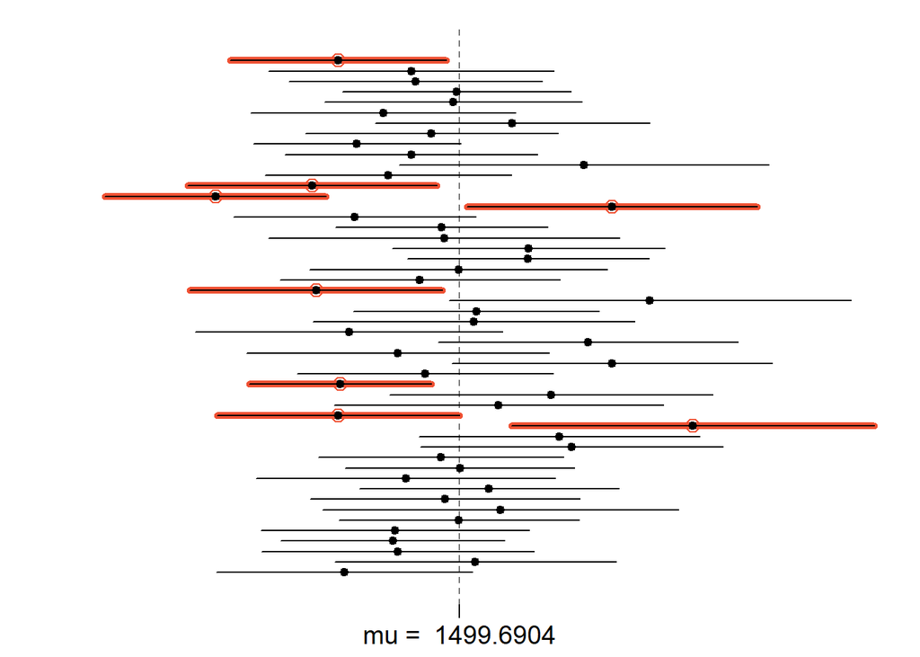

```r
act_samp_mean <- rep(NA, 50)
act_samp_sd <- rep(NA, 50)
act_n <- 60
for(i in 1:50){
  act_samp <- sample(population, act_n)
  act_samp_mean[i] <- mean(act_samp)
  act_samp_sd[i] <- sd(act_samp)
}
act_lower_vector <- act_samp_mean - 1.64 * act_samp_sd / sqrt(act_n)
act_upper_vector <- act_samp_mean + 1.64 * act_samp_sd / sqrt(act_n)

plot_ci(act_lower_vector, act_upper_vector, mean(population))
```

```r
act_num_within <- 0
for (i in 1:50){if((act_lower_vector[i] <= mean(population))&(act_upper_vector[i] >= mean(population))){act_num_within<- act_num_within + 1}}
```

### The proportion of confidence intervals that capture the population mean is **0.84** at a 90% confidence level. This is **lower** than that of a 95% confidence level.